UX 评审 · 2026-10-18

# 沐仞小程序 UI 预览

对象 **[mini-preview](https://xanthiawang.github.io/fathompeak-site/mini-preview/)**（版本 f655bc6） 方法 **设计评审 + 自动检测**（两路独立评估） 视口 **390 × 844 / 320 × 700** 身份 **个人 · 企业管理员 · 企业成员**

设计健康分

20 / 40

可接受 · 需要明显改进

P1 × 3P2 × 2

视觉辨识度很高，但产品叙事断在"价格"这一步。用户先看到 ¥0.00 和"立即充值"，整个流程里却找不到"我实际付多少"；每条路径最后都停在一个灰色的禁用按钮上。最大的机会是把"4 折"变成看得见的数字。

01 · 尼尔森十项启发式

## 健康分明细

| # | 维度 | 得分 | 关键问题 |
| --- | --- | --- | --- |
| 1 | 系统状态可见性 | **2** | 算费用的结果在首屏以下，报错被底栏挡住；从模型市场进入充值后，底栏高亮跳到"我的" |
| 2 | 用语贴近用户 | **2** | "百万 Token""计费档""方案预览"偏内部；厂商写 Alibaba / Zhipu，国内用户更熟"通义 / 智谱" |
| 3 | 用户控制与退出 | **3** | 从用量账单进入充值订单，返回却回到"我的" |
| 4 | 一致性 | **1** | 充值按钮蓝色、其他主按钮墨色；计费说明有四个名字；用量账单出现两个 ¥；自制按钮占了微信胶囊位 |
| 5 | 防错 | **2** | 全角数字被拒绝且没有提示；单位只在占位提示里；必填单价藏在折叠区；充值没有金额档位 |
| 6 | 识别而非回忆 | **1** | 算费用要用户自己去查官方单价；测算结果不能带进充值 |
| 7 | 效率 | **2** | 没有快捷金额、"按这个金额充值"，也不能把接入配置发送到电脑 |
| 8 | 简洁 | **2** | 余额加充值在三个底栏重复；礼包和教育卡重复；免责文字太密 |
| 9 | 错误恢复 | **2** | 四个输入框共用一句报错；超大金额也提示"请填写大于 0" |
| 10 | 帮助 | **3** | 计费说明和接入文档都有，但外链、`../#console`、`mailto:` 在小程序里打不开 |
|  | 合计 | 20 / 40 · 可接受（20–27 分档） |  |

02 · 设计是否为本产品定制

## 视觉是沐仞的，结构是通用的

### 视觉：专属

排线插画（钥匙、天平、罗盘、握手山峦）、Fraunces 衬线数字、晨蓝与暮紫、缓动树影，一看就是沐仞，延续了官网。

### 结构：通用

"余额卡 + 立即充值 + 权益双卡 + 菜单列表"，任何钱包或充值类小程序都能套用。真正的卖点没有变成界面元素。

**最关键的一点：**"公开价 4 折起"没有出现在任何一个价格上。列表主数字是 10 月 13 日的历史公开价，还用了品牌蓝，容易被读成沐仞价。"待同步 / 待确认 / 待配置"每屏出现 3–4 次，存在感比产品本身还强。

03 · 优先问题

## 先改这五件事

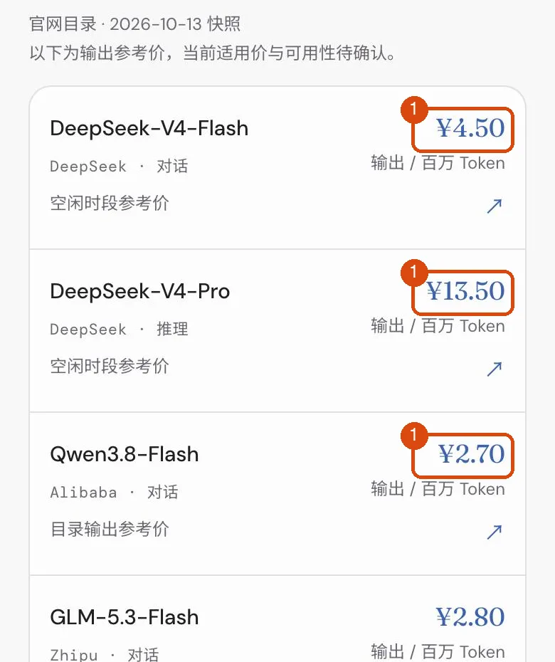

1蓝色大号数字是历史公开价，不是沐仞价。

P1

### 卖点没有落到价格上

**为什么重要**

用户回答不了"我实际付多少"。蓝色大号的公开价会被当成沐仞价，后面会变成信任问题。详情页的"当前适用输出价"也写着"折扣单价待同步"。

**怎么改**

- 价格表没出来之前，公开价降成中性灰，旁边写"公开参考价 · 沐仞价待公布"，不再用品牌蓝。
- 价格表到位后改成两层：公开价划线，沐仞价做蓝色主数字。

**建议命令**

/impeccable clarify

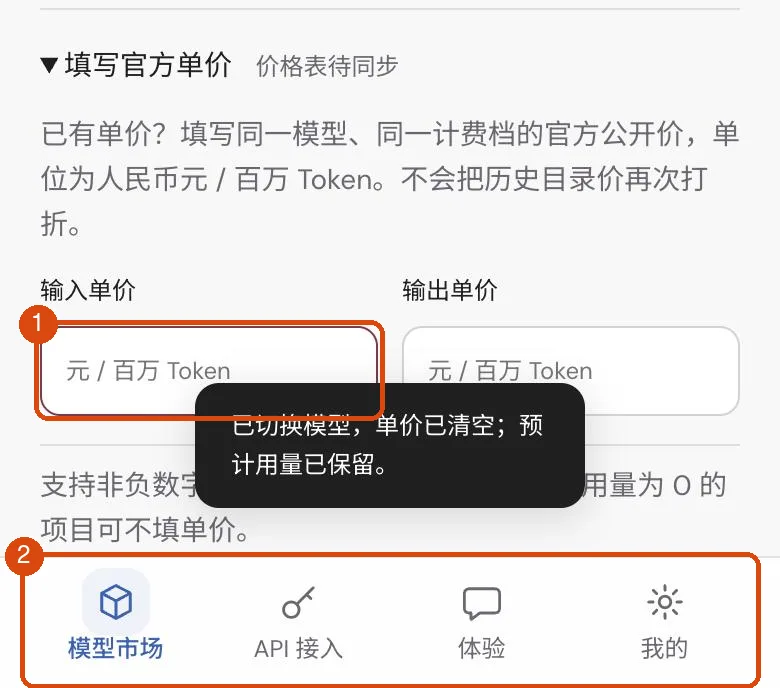

1没填单价时只有这个框变红；2报错文字在 y=783，被底栏（y=778 起）挡住。

P1

### 算算费用要用户自己去找单价

**为什么重要**

这一屏本该是转化的高点（"预计节省 ¥60"），却最费力：新用户不知道官方单价，结果在首屏以下，算完也不能带进充值。

**怎么改**

- 按模型预填公开单价（注明来源和日期），可以改，默认展开。
- 用量给 1M / 10M / 100M 快捷档。
- 结果固定在底栏上方，加"按此金额充值"。
- 报错写明是哪个框；全角数字先转半角再校验。

**建议命令**

/impeccable harden

[figure not shown]

1自制的 ••• 和 ◎ 占了微信胶囊位；2头图文字对比度 3.6–3.7:1；3第一眼最强的是 ¥0.00 和"立即充值"。

P1

### 和微信平台冲突

**为什么重要**

真机上右上角胶囊是微信自己的菜单和退出按钮，自制的"更多"和"关于预览"会失效，服务说明和动效开关跟着没了入口。代码里还有 8 处 `target="_blank"` 外链、`../#docs` 一类跳转和 `mailto:`，在小程序里都打不开。

**怎么改**

- 胶囊区留空，"服务说明"和"动效开关"移进"我的"。
- 外链改成"复制链接"，或挂到已配置的业务域名下。
- 网页控制台入口改成"扫码在电脑登录"。

**建议命令**

/impeccable adapt

[figure not shown]

1蓝色主按钮；2墨色主按钮；3同一页第二个"创建 Key"。

P2

### 用词和主按钮不统一

**问题**

- 表示钱：余额、额度、可用额度、企业分配额度、企业可用额度。
- 表示付钱：充值、购买、补充额度、充值购买。
- 计费说明有四个名字：计费说明、Token 与计费说明、服务说明、折扣与计费。
- 充值按钮蓝色，其他主按钮墨色；API 页同时有两个主按钮。
- 用量账单页"账户余额 · ¥"后面又跟"¥0.00"（见下图）。

**怎么改**

定一张词表（账户余额、充值、Token 用量、企业额度）；主按钮统一一种颜色，每屏只有一个；↗ 只用在离开小程序的链接上。

**建议命令**

/impeccable clarify

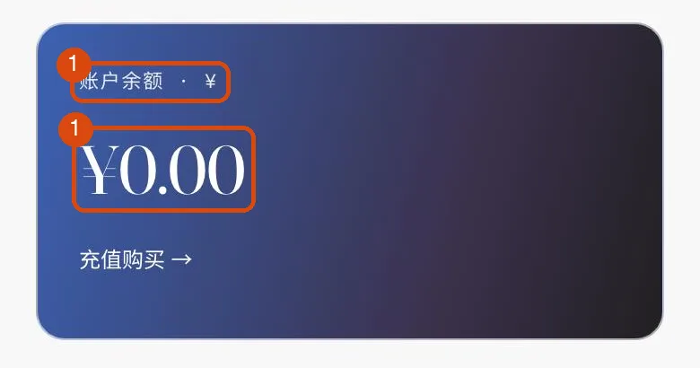

1两个 ¥。

[figure not shown]

2"4 折起""计费说明"压在模糊树影图上，对比度不足。

P2

### 对比度与触控尺寸

**检测结果**

- 首页头图："4 折起" 3.6:1、"4" 3.7:1、"计费说明 ↗" 3.7:1、"账户余额" 4.46:1（要求 4.5:1）。
- 小于 44px 的点击区：通知 32×28、返回键高 36、筛选胶囊高 36、"创建 Key ＋"等文字按钮高 40。
- 标签 11px；占位提示约 3.3:1，单位还写在占位提示里。

**怎么改**

头图文字区加一层浅色底或降低图片透明度；点击区不小于 44；标签不小于 12px；单位做成输入框后缀。

**建议命令**

/impeccable polish

04 · 做得好的

## 值得保留

### 视觉延续官网

排线插画、衬线数字、克制配色，在卖 Token 的同类产品里少见。

### 口径诚实，身份一致

写明充值进统一余额、不换算固定 Token 数；企业成员在首页、详情、算费用、体验、充值各处都正确换成"联系管理员"。

### 表单与无障碍底子

数字键盘、报错时聚焦到对应输入框、弹窗关闭后焦点归还、遵循系统"减少动态效果"。

05 · 典型用户会卡在哪里

## 三种用户的真实阻碍

第一次使用

- 第一眼是 ¥0.00 和"立即充值"，模型要往下滑两屏。
- 分不清 ¥4.50 是不是自己要付的价。
- 不知道官方单价去哪找。
- ¥68 礼包写着"待确认"，按钮又是灰的，像被诱导。

单手、注意力分散

- "充值并接入""下一步"都不吸底。
- 弹窗居中，关闭在右上角，单手够不到。
- 测算一刷新就清空。
- 在手机上复制了接入配置，但要在电脑上用。

依赖无障碍功能

- 点击区偏小，标签 11px。
- 报错被底栏挡住，也不说哪个框。
- 同一图标表示不同东西：太阳 = "我的"和"教育优惠"；对话气泡 = "体验"和"帮助"。
- "↗""←"会被读屏软件念出来。

06 · 次要问题与更正

## 顺手要修的

- 每个返回行右边都有"沐仞 · AI 服务"，没有信息量。
- 390 宽度下企业采购卡的"采购"断成两行。
- 算费用按钮下方、礼包弹窗里有几处零间距。
- 企业成员也能看到礼包、充值订单等用不了的入口。
- "我的"没有昵称、账户 ID，也没有退出。
- 样式表里同一选择器被覆盖 3–4 次，以后改起来风险高。

### 评审中更正的两点

"复制模型名复制的是显示名"不算问题：README 写明 model 参数用目录里的完整 name，是有意定的。

"iOS 不能充值"的说法过时：微信 2026 年 2 月已开放 iOS 小程序虚拟支付，Token 充值要按虚拟支付接入。

07 · 值得追问

## 三个问题

整个卖点是"4 折"，为什么没有任何一屏出现过 4 折后的价格？

开发者真会在手机上配置 API 吗？小程序是否应该只管付钱、看用量、余额提醒和扫码登录网页控制台？

每条路径都停在禁用状态。我们评审的是产品，还是这份预览有多诚实？要不要在评审导航里加"到账成功、Key 一次性展示"的示意帧？

08 · 方法与证据

## 怎么得出的

### 设计评审

独立走查四个底栏、模型详情、算算费用（含错误输入）、充值到确认、用量账单、调用明细、充值订单、API 配置、各弹窗；切换三种身份；390 和 320 两种宽度。

### 自动检测

源文件扫描无问题（Fraunces 为项目配置豁免的品牌字体）。按 390 × 844 渲染后扫描首页 5 条：卡片套卡片 1 条（合并余额条，属有意设计）、对比度不足 4 条。页面内检测在首页和"我的"各发现 1 条卡片套卡片。无报错、无横向溢出、所有按钮都有可读名称。

截图为 2026-10-18 本地预览实拍，标注框为评审添加。存档：`官网源码/.impeccable/critique/2026-10-18T11-51-34Z__mini-preview-index-html.md`